# Econometric Models

The Linear Model, Binary Choice, and a Tour of the Toolbox

## What Is an Econometric Model?

An econometric model links an **outcome** $Y$ to **explanatory variables** $X$ and to everything else we do not observe, $u$:

$$Y = f(X) + u$$

Most of the time we model the **conditional mean** $E[Y \mid X]$ — the average outcome among people who share the same $X$.

**Describe**

How do wages differ across education levels?

**Predict**

How likely is this applicant to default?

**Explain**

What does one more year of school **do** to a wage?

The same regression serves all three — but the third needs the most assumptions.

## Three Outcomes, Three Shapes

The **type of outcome** decides which model fits. This deck walks through them in order.

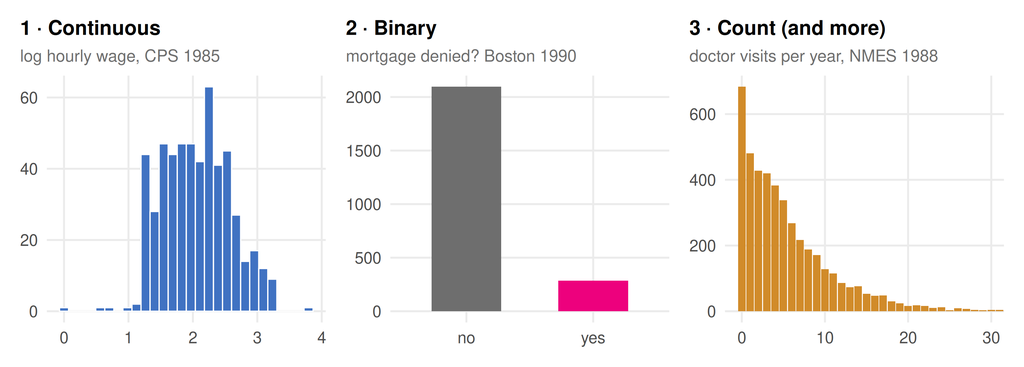

**Linear model** for the first, **logit / probit** for the second, and a **family of specialised models** for the rest.

# 1 · The Linear Model

## Does Education Pay?

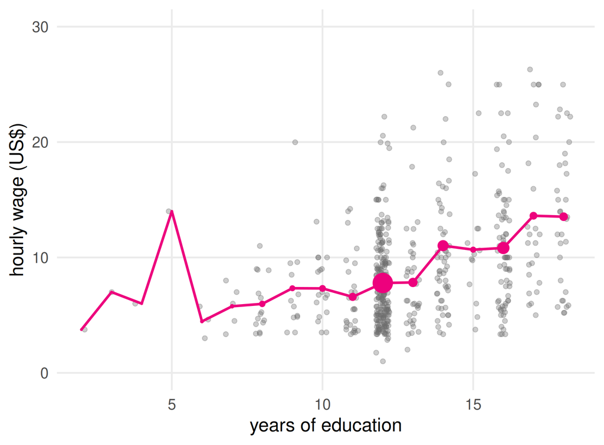

**Data:** `CPS1985` from the `AER` package — 534 US workers.

- Each grey dot is **one worker**
- Each pink dot is the **average wage** at that education level: $E[\text{wage} \mid \text{educ}]$
- Dot size = number of workers

**The idea of regression**

Summarise the pink dots with a simple formula — a **line**.

## Why Log Wages?

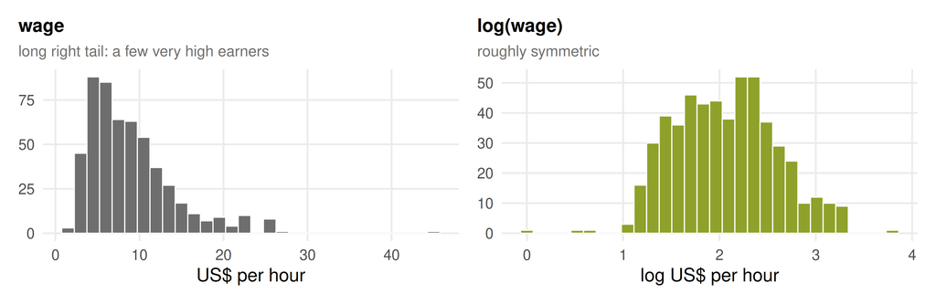

**Statistical reason**

Wages are **skewed**; the log pulls in the tail, so a few extreme earners do not dominate the fit.

**Economic reason**

Education plausibly raises wages by a **percentage**, not by a fixed dollar amount. In logs, coefficients read as **% changes**.

## The Linear Model

$$\log(\text{wage}_i) = \underbrace{\beta_0 + \beta_1\,\text{educ}_i}_{E[Y \mid X]:\ \text{systematic part}} \; + \underbrace{u_i}_{\text{everything else}}$$

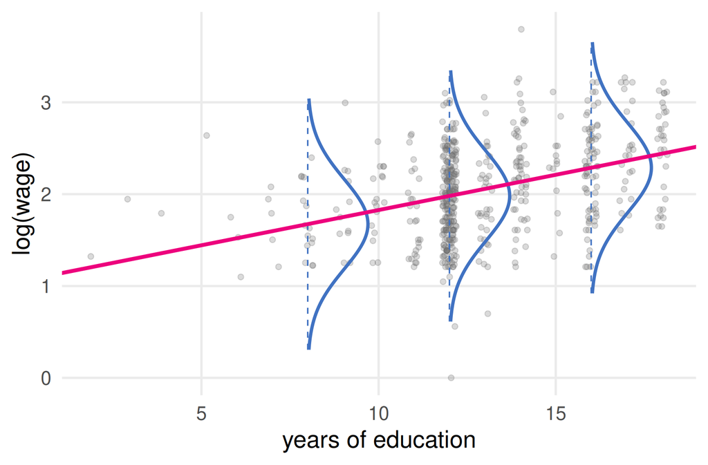

- The **pink line** is $E[Y \mid X]$: where the average sits at each education level
- The **blue curves** are the spread of $u$ around it: many people above, many below

**The key assumption**

$E[u \mid \text{educ}] = 0$: whatever is left in $u$ averages to **zero at every education level**. Then the line really is the conditional mean.

## Least Squares, Live

Choose the line yourself. Least squares picks the one with the **smallest sum of squared residuals** (SSR).

[interactive chart not shown]

60 workers drawn from `CPS1985`. Each vertical segment is a **residual** $y_i - \hat y_i$: pink above the line, blue below.

The orange dot is the point of means $(\bar x, \bar y)$. The least-squares line always passes through it, so **shift = 0** is always part of the answer.

[interactive chart not shown]

## Running It in R

```r
m1 <- lm(log(wage) ~ education, data = CPS1985)
summary(m1)
```

```
Call:
lm(formula = log(wage) ~ education, data = CPS1985)

Residuals:
     Min       1Q   Median       3Q      Max
-1.98099 -0.37155  0.03391  0.34975  1.66098

Coefficients:
            Estimate Std. Error t value Pr(>|t|)
(Intercept) 1.059890   0.107432   9.866   <2e-16 ***
education   0.076759   0.008091   9.487   <2e-16 *** 123
---

Residual standard error: 0.4885 on 532 degrees of freedom 4
Multiple R-squared:  0.1447,    Adjusted R-squared:  0.1431  5
F-statistic: 90.01 on 1 and 532 DF,  p-value: < 2.2e-16
```

1 **Estimate.** One more year of education goes with $0.077$ higher log wage — about **+8%** ($e^{0.077}-1$).

2 **Std. Error.** How much the estimate would move from sample to sample.

3 **t value** $=$ estimate / SE, and its **p-value** for $H_0: \beta_1 = 0$. Here: no doubt that $\beta_1 \neq 0$.

4 **Residual SE.** The typical size of $u$: about $0.49$ log points.

5 **R².** Education accounts for **14%** of the variation in log wages. The F-statistic tests all slopes $=0$ at once.

## Standard Errors Are Sampling Variability

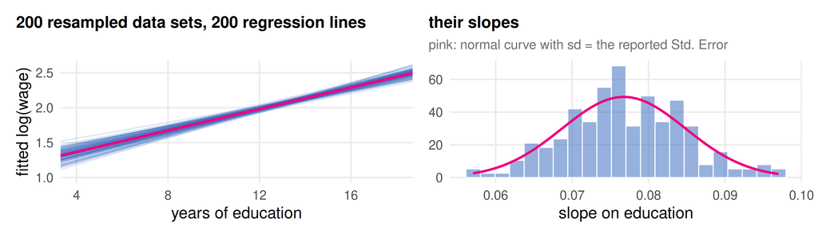

```r
confint(m1)
```

```
                 2.5 %     97.5 %
(Intercept) 0.84884618 1.27093355
education   0.06086475 0.09265238
```

The **Std. Error** is the width of that histogram — no resampling needed, R computes it from one sample. The 95% interval is roughly **estimate ± 2 SE**: a return of **6% to 9%** per year.

## Reading Coefficients: Units Matter

| Model | Formula in R | Interpretation of $\beta_1$ |
| --- | --- | --- |
| **level–level** | `lm(wage ~ educ)` | +1 year $\Rightarrow$ wage changes by $\beta_1$ **dollars** |
| **log–level** | `lm(log(wage) ~ educ)` | +1 year $\Rightarrow$ wage changes by about $100\cdot\beta_1$ **%** |
| **level–log** | `lm(wage ~ log(sales))` | +1% sales $\Rightarrow$ wage changes by $\beta_1/100$ **dollars** |
| **log–log** | `lm(log(q) ~ log(p))` | +1% price $\Rightarrow$ quantity changes by $\beta_1$ **%** — an **elasticity** |

**Exact, not approximate**

In log–level models the exact change is $e^{\beta_1} - 1$. For $\beta_1 = 0.077$: $7.98\%$. For small $\beta$ the two agree; for $\beta = -0.26$ they do not ($-22.7\%$).

**Always state the units**

“The coefficient is 0.077” means nothing on its own. “One more year of schooling goes with about 8% higher hourly wages” is an answer.

## More Than One Regressor

```r
m2 <- lm(log(wage) ~ education + experience + I(experience^2) +
           gender, data = CPS1985)
summary(m2)
```

```
Coefficients:
                  Estimate Std. Error t value Pr(>|t|)
(Intercept)      0.6007445  0.1194927   5.027 6.81e-07 ***
education        0.0912936  0.0080049  11.405  < 2e-16 *** 1
experience       0.0360522  0.0054352   6.633 8.14e-11 *** 2
I(experience^2) -0.0005412  0.0001197  -4.520 7.64e-06 *** 3
genderfemale    -0.2570355  0.0387066  -6.641 7.77e-11 *** 4

Residual standard error: 0.4442 on 529 degrees of freedom
Multiple R-squared:  0.2968,    Adjusted R-squared:  0.2915  5
F-statistic: 55.81 on 4 and 529 DF,  p-value: < 2.2e-16
```

Each coefficient is now an effect **holding the other regressors fixed** — *ceteris paribus*.

1 Return to education **rises** from 0.077 to 0.091. Why? Next slide.

2 3 Experience raises wages, but by **less and less** — the square lets the profile bend.

4 Women earn about **23% less** ($e^{-0.257}-1$) at the same education and experience.

5 Adjusted R² penalises extra regressors; it doubled.

## Why Did the Education Coefficient Move?

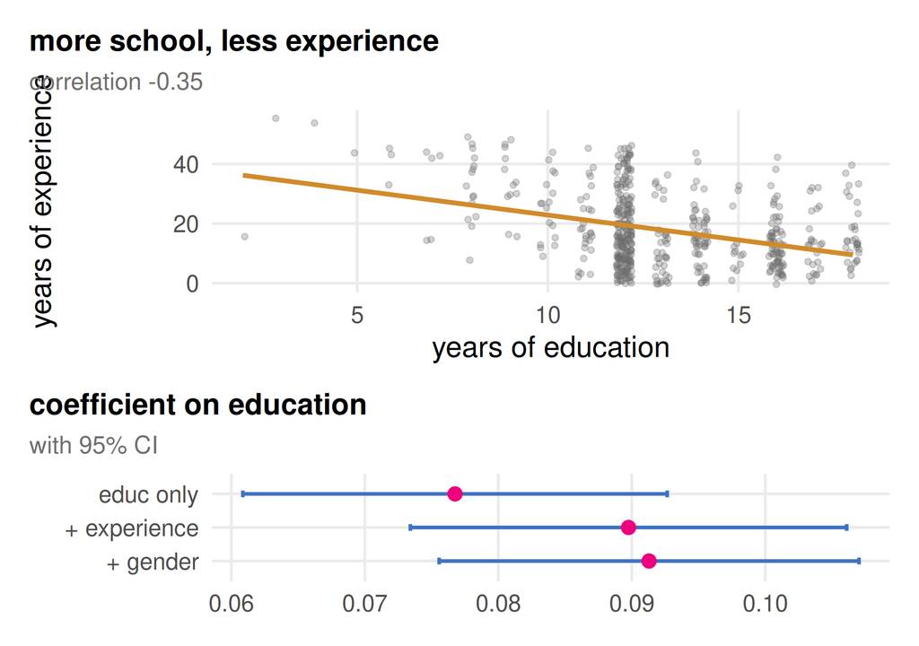

Leaving **experience** out of the model puts it into $u$. It is **not** harmless there:

- experience **raises** wages ($+$)
- experience is **lower** for the more educated ($-$)

**Omitted variable bias**

bias $=$ (effect of the omitted variable on $Y$) $\times$ (how it moves with $X$)

Here $(+)\times(-)$: the short regression **understates** the return to education.

## Curves Are Still “Linear” Models

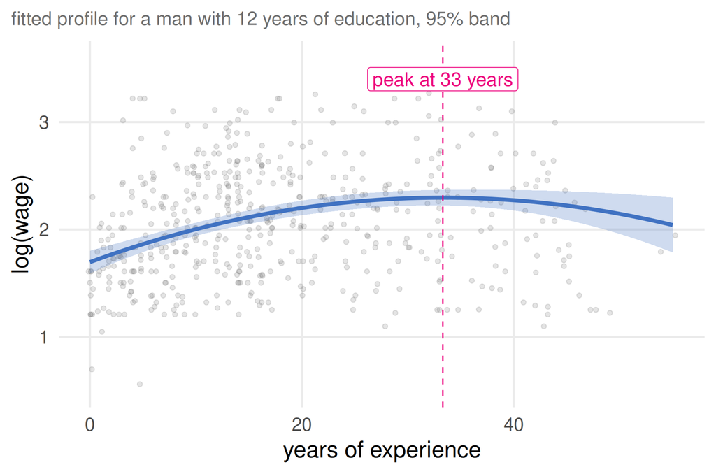

$$\ldots + \beta_2\,\text{exper} + \beta_3\,\text{exper}^2$$

“Linear” means linear in the **coefficients** $\beta$, not in $X$. Squares, logs and interactions all work in `lm()`.

One more year of experience now adds $\beta_2 + 2\beta_3\,\text{exper}$: a lot early in a career, **zero at the peak** $-\hat\beta_2 / (2\hat\beta_3) \approx 33$ years.

**In R**

Write `I(experience^2)` — inside a formula, a bare `^` means something else.

## Dummy Variables Shift the Line

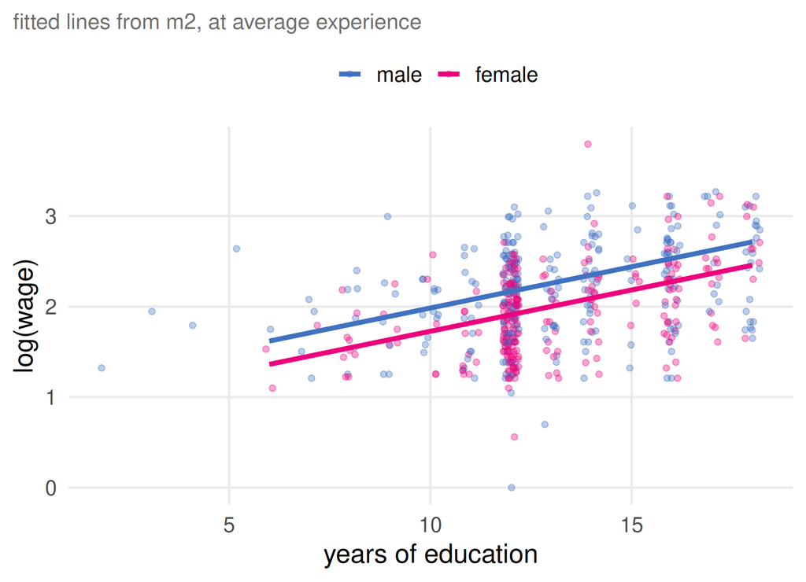

`gender` is a **factor**; R turns it into a 0/1 dummy `genderfemale` automatically. The first level (`male`) is the **reference group**.

The dummy moves the **intercept**:

- men: $\beta_0 + \ldots$
- women: $(\beta_0 - 0.257) + \ldots$

**Parallel by construction**

The gap is the **same at every education level** — because we assumed it, not because the data said so. To let it differ, interact.

## Interactions Let the Slopes Differ

```r
m3 <- lm(log(wage) ~ education * gender + experience +
           I(experience^2), data = CPS1985)
```

```
Coefficients:
                         Estimate Std. Error t value Pr(>|t|)
(Intercept)             0.7896897  0.1402019   5.633 2.89e-08 ***
education               0.0762191  0.0099290   7.676 7.97e-14 *** 1
genderfemale           -0.7539256  0.1992145  -3.784 0.000172 *** 2
experience              0.0369215  0.0054182   6.814 2.59e-11 ***
I(experience^2)        -0.0005585  0.0001193  -4.681 3.64e-06 ***
education:genderfemale  0.0381424  0.0150037   2.542 0.011300 *   3
```

1 Return to education for **men**: 7.6%.

2 Gender gap at **zero** education — an extrapolation, do not read it alone.

3 **Extra** return for women: $0.076 + 0.038 = 0.114$ per year.

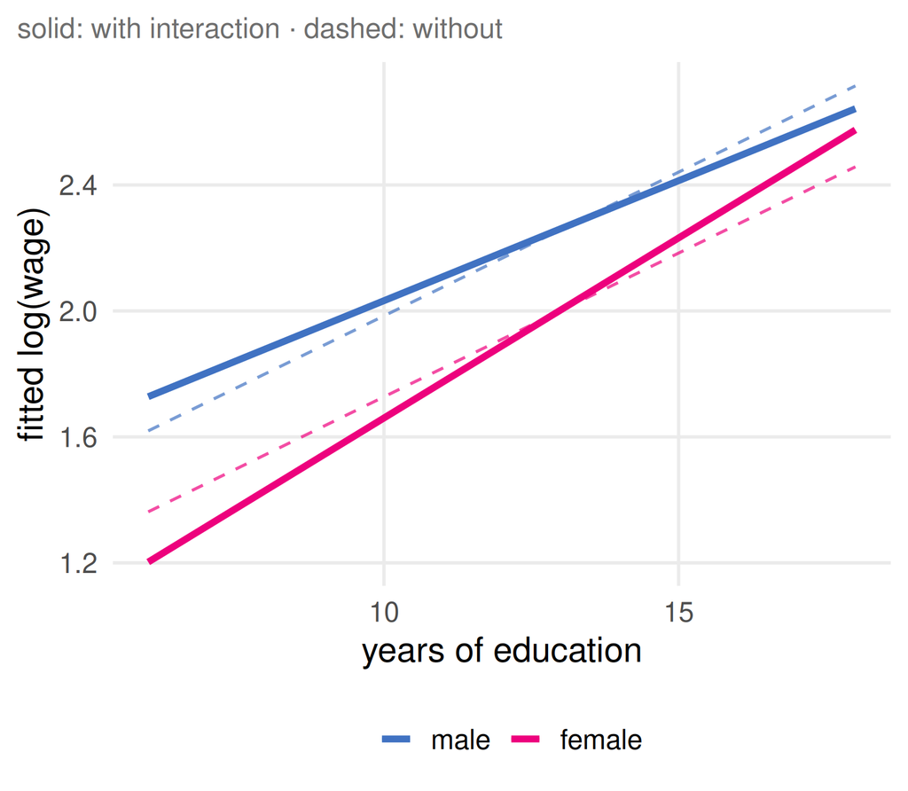

The gender gap **narrows** with education.

## Testing Several Coefficients at Once

The $t$-test in `summary()` checks **one** coefficient. To ask “do experience and gender matter **at all**?” compare the two models with an **F-test**:

```r
anova(m1, m2)
```

```
Analysis of Variance Table

Model 1: log(wage) ~ education
Model 2: log(wage) ~ education + experience + I(experience^2) + gender
  Res.Df    RSS Df Sum of Sq      F    Pr(>F)
1    532 126.97                                   1
2    529 104.39  3    22.576 38.134 < 2.2e-16 *** 23
```

1 SSR of the **restricted** model — experience and gender set to zero.

2 SSR of the **full** model: 3 extra coefficients, 22.6 less squared error.

3 Is that drop larger than chance would produce? $F = 38$, $p \approx 0$: **yes**.

**The logic from the testing deck**

Same recipe as before: a test statistic, its distribution under $H_0$, a p-value. `car::linearHypothesis()` tests any other linear restriction, e.g. $\beta_\text{exper} = \beta_\text{educ}$.

## The Assumptions, in Plain Words

| Assumption | In words | What fails without it |
| --- | --- | --- |
| **Linear in parameters** | $Y$ is a sum of $\beta \times$ (something built from $X$) | The fitted line is the wrong shape |
| **Random sample** | Observations are independent draws from the population | Standard errors — see clustering |
| **No perfect collinearity** | No regressor is an exact combination of others | R cannot separate them: `NA` coefficient |
| **Exogeneity** $E[u \mid X] = 0$ | The omitted stuff is unrelated to $X$ | **The estimates themselves are biased** |
| **Homoskedasticity** | The spread of $u$ is the same for every $X$ | Only the usual standard errors |
| **Normal errors** | $u$ is normally distributed | Nothing, once $n$ is moderate (CLT) |

**Two very different kinds of failure**

The first four give you the **right number**. The last two only give you the **right uncertainty** — and are easy to fix. Exogeneity is the one that keeps econometricians busy.

## Heteroskedasticity: Look at the Residuals

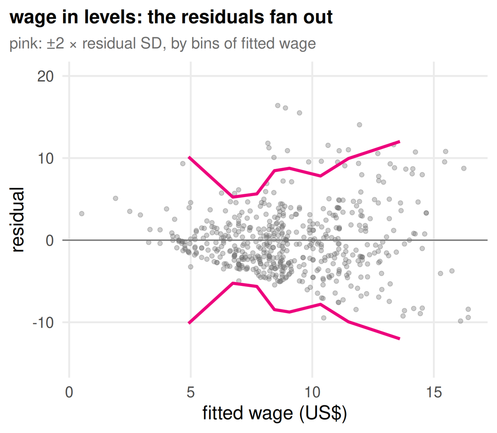

```r
m0 <- lm(wage ~ education + experience +
           I(experience^2) + gender, data = CPS1985)
round(cbind(usual  = sqrt(diag(vcov(m0))),
            robust = sqrt(diag(vcovHC(m0, type = "HC1")))), 4)
```

```
                 usual robust
(Intercept)     1.1888 1.2493
education       0.0796 0.0880
experience      0.0541 0.0631
I(experience^2) 0.0012 0.0013
genderfemale    0.3851 0.3936
```

- The **estimates do not change** — only the standard errors
- Robust (“sandwich”, HC1) SEs are valid **whether or not** the spread is constant
- In a table of results: `coeftest(m0, vcov = vcovHC(m0, type = "HC1"))`

**Rule of thumb**

Use robust standard errors **by default**.

## Regression Is Not Yet Causation

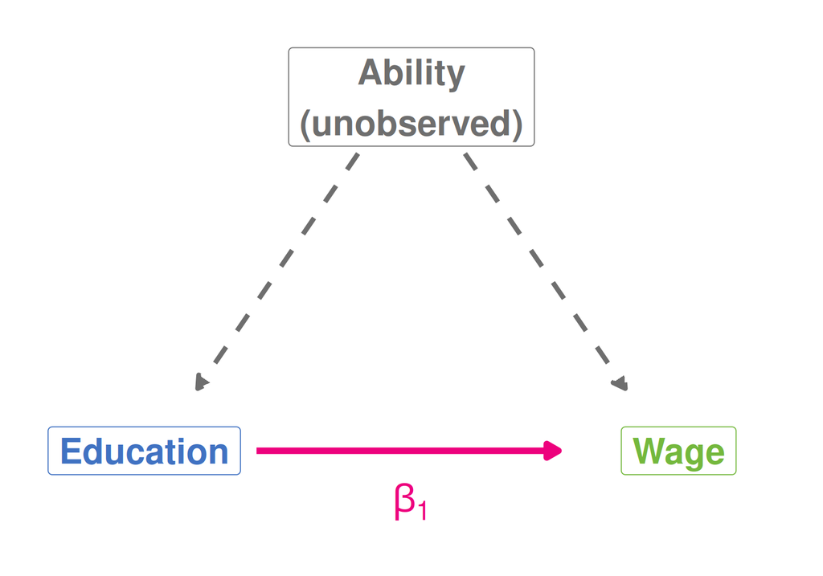

Ability raises **both** schooling and wages. It sits in $u$, so $E[u \mid \text{educ}] \neq 0$ and $\hat\beta_1$ mixes the effect of school with the effect of ability.

**What $\hat\beta_1 = 0.077$ is**

A well-estimated **conditional mean difference**: how wages differ between people with different schooling.

**What it is not (yet)**

The effect of **sending** someone to school for one more year. That needs a design — **panel data, IV, DiD** in part 3.

# 2 · Binary Choice

## When the Outcome Is Yes or No

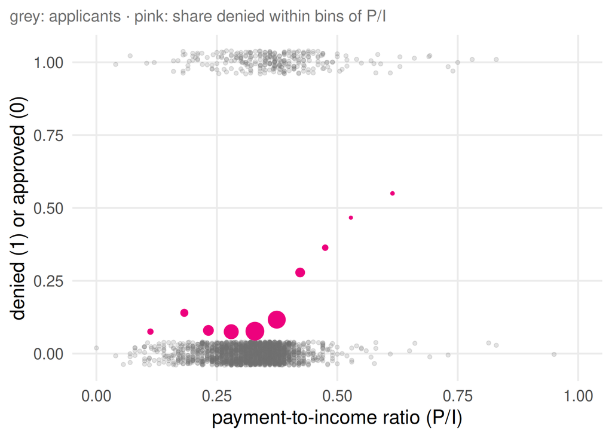

Labour-force participation, loan default, buying a car, migrating, voting: many outcomes are **0 or 1**.

**Data:** `HMDA` — 2,380 Boston mortgage applications, **12% denied**. The key regressor is the ratio of monthly debt payments to income.

**The conditional mean is a probability**

For $Y \in \{0,1\}$:
$$E[Y \mid X] = P(Y = 1 \mid X)$$
So a model for $E[Y\mid X]$ is a model for the **probability** of a yes.

## The Linear Probability Model

Just run OLS on the 0/1 outcome — a **linear probability model** (LPM):

```r
lpm <- lm(I(deny == "yes") ~ pirat, data = HMDA)
coeftest(lpm, vcov = vcovHC(lpm, type = "HC1"))
```

```
t test of coefficients:

             Estimate Std. Error t value  Pr(>|t|)
(Intercept) -0.079910   0.031967 -2.4998   0.01249 *   3
pirat        0.603535   0.098483  6.1283 1.036e-09 *** 12
```

1 Coefficients are **changes in probability**: $+0.1$ in P/I raises the denial probability by $0.06$ — **6 percentage points**.

2 Robust SEs are **mandatory** here: with a 0/1 outcome, $\text{Var}(u \mid X) = p(1-p)$ changes with $X$ by construction.

3 The intercept is a **negative probability**. That is a warning sign.

**Why people like it**

Easy to fit, easy to read, and its slopes are usually close to the average effects of the fancier models. A sensible first look.

## Where the Straight Line Breaks

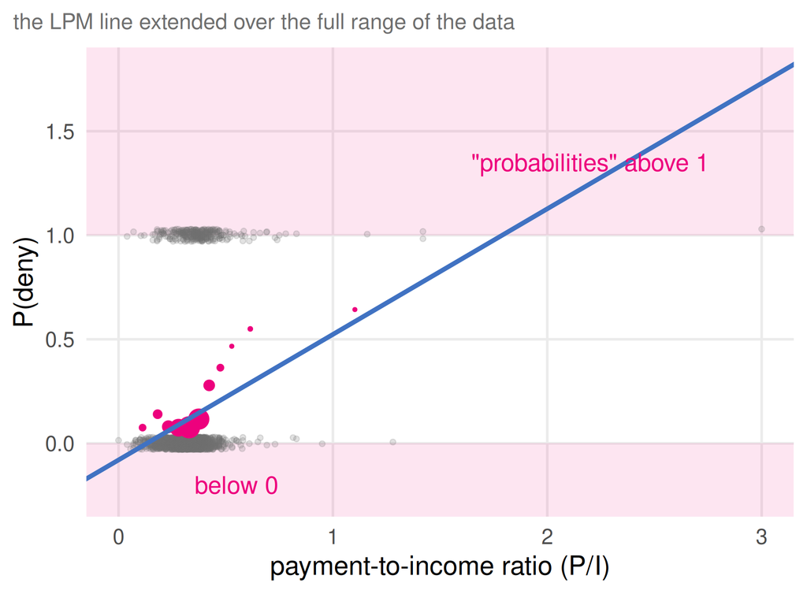

- **Impossible predictions.** At P/I = 3 (it happens) the LPM predicts a denial probability of 1.73
- **Constant effects.** +0.1 in P/I adds 6 points whether you start at 1% or at 95% — but near 0 and 1 a probability **cannot** keep moving at the same pace
- **Built-in heteroskedasticity** — fixed by robust SEs

**What we want**

A curve that stays inside $[0, 1]$ and **flattens** at both ends.

## Bend the Line: The S-Curve

$$P(Y = 1 \mid X) = G(\beta_0 + \beta_1 X), \qquad G:\ \mathbb{R} \to [0, 1] \text{ increasing}$$

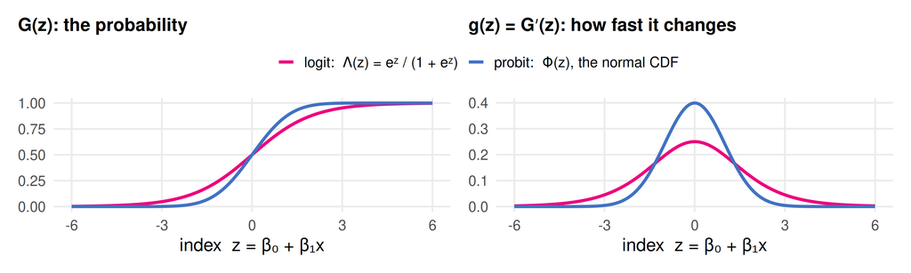

**Two choices of G**

**Logit** uses the logistic CDF, **probit** the normal CDF. Same shape; the logistic has fatter tails.

**Different scales**

The logistic is more spread out, so logit coefficients are about **1.6×** probit coefficients. Only the **probabilities** are comparable.

## Where the S-Curve Comes From, Live

Each applicant has a latent “denial score” $y^* = \beta_0 + \beta_1 x + \varepsilon$. The bank denies if $y^* > 0$. So $P(\text{deny}) = P(\varepsilon > -\beta_0 - \beta_1 x) = G(\beta_0 + \beta_1 x)$.

[interactive chart not shown]

Coefficients are the ones fitted to `HMDA` on the next slides.

**Left:** the distribution of $y^*$ for applicants with this $x$. The shaded area beyond 0 is the probability of denial.

**Right:** that area, traced out over $x$. The dashed tangent is the **marginal effect** at this $x$: density $\times\ \beta_1$.

[interactive chart not shown]

## Estimation: Maximum Likelihood

There is no “residual” to square. Instead ask: which $\beta$ makes the **observed** denials and approvals most probable?

- a denied applicant contributes $p_i = G(\beta_0 + \beta_1 x_i)$
- an approved one contributes $1 - p_i$

$$\ell(\beta) = \sum_{i} \Big[ y_i \log p_i + (1 - y_i) \log(1 - p_i) \Big]$$

R climbs this function numerically — no formula like OLS.

**From the estimation deck**

This is the MLE recipe exactly. Every likelihood is a loss; OLS was the special case with normal errors.

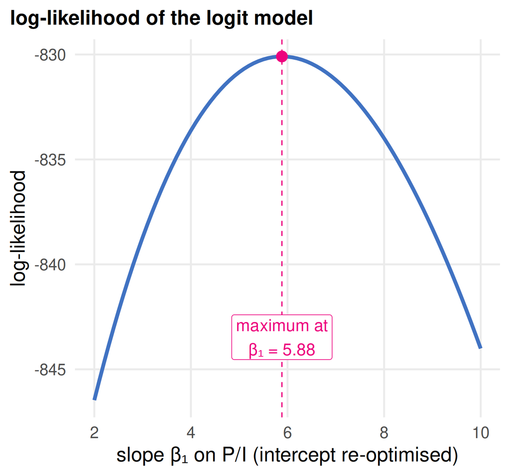

## Logit in R

```r
lg <- glm(deny ~ pirat, family = binomial(link = "logit"),
          data = HMDA)
summary(lg)
```

```
Coefficients:
            Estimate Std. Error z value Pr(>|z|)
(Intercept)  -4.0284     0.2686 -14.999  < 2e-16 ***
pirat         5.8845     0.7336   8.021 1.05e-15 *** 12

    Null deviance: 1744.2  on 2379  degrees of freedom
Residual deviance: 1660.2  on 2378  degrees of freedom 3
AIC: 1664.2 4

Number of Fisher Scoring iterations: 5 5
```

1 The coefficient is on the **index** $\beta_0 + \beta_1 x$, i.e. on the **log-odds**. Its **sign** and **significance** are readable; its size is not a probability.

2 **z value**, not $t$: MLE standard errors rely on large samples.

3 **Deviance** $= -2 \times$ log-likelihood. The drop from the null deviance (1744) is a likelihood-ratio test of the slope.

4 **AIC**: deviance + a penalty for parameters; smaller is better when comparing models.

5 Steps of the numerical optimiser.

## Making the Coefficient Speak

**Odds ratios** — logit only:

```r
exp(coef(lg))
```

```
 (Intercept)        pirat
  0.01780222 359.42220584
```

```r
exp(0.1 * coef(lg)["pirat"])   # per 0.1 of P/I
```

```
   pirat
1.801194
```

Raising P/I by 0.1 multiplies the **odds** of denial, $p/(1-p)$, by 1.8. Common in medicine; many find odds hard to think in.

**Predicted probabilities** — always work:

```r
predict(lg, newdata = data.frame(pirat = c(0.3, 0.5)),
        type = "response")
```

```
         1          2
0.09422692 0.25233766
```

Moving from P/I 0.3 to 0.5 raises the denial probability from **9% to 25%**. `type = "response"` returns $G(\hat\beta_0 + \hat\beta_1 x)$; the default `"link"` returns the index.

**What you can read straight from the logit table**

**Sign** (direction), **significance** (whether), and **ratios** of two coefficients (relative importance). Not: “how many percentage points”.

## Logit, Probit, LPM: Same Story

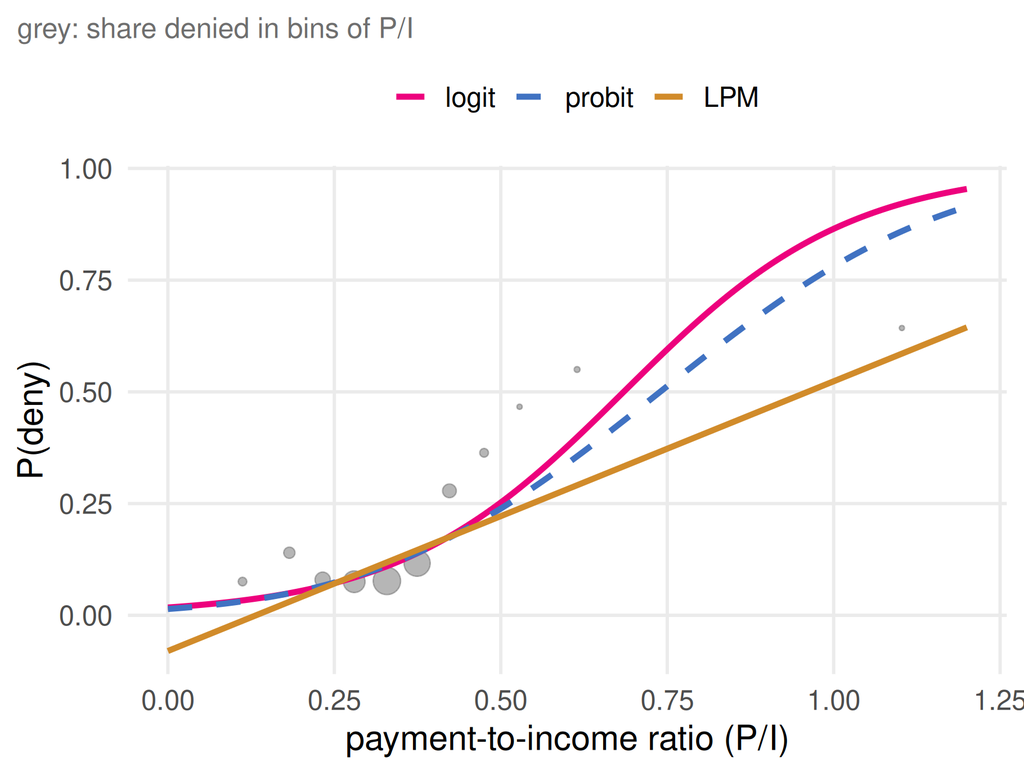

```r
rbind(logit  = coef(lg),
      probit = coef(pb),
      LPM    = coef(lpm))
```

```
       (Intercept)     pirat
logit  -4.02843220 5.8844978
probit -2.19414501 2.9678666
LPM    -0.07990965 0.6035349
```

- **Coefficients** differ a lot: 5.9 vs 3.0 vs 0.6 — different scales, not different findings
- **Predicted probabilities** are nearly identical where the data are
- Logit vs probit is rarely a substantive choice. Pick one and report **probabilities** or **marginal effects**

## Marginal Effects Vary Along the Curve

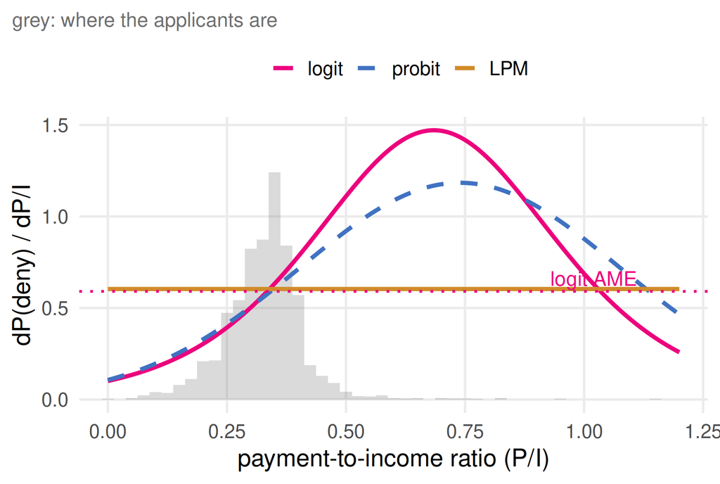

In logit/probit the effect of $x$ on the probability is

$$\frac{\partial P}{\partial x} = g(\beta_0 + \beta_1 x)\cdot\beta_1$$

— it **depends on where you stand**. Two ways to boil it down to one number:

**Two one-number summaries**

**AME** (average marginal effect): the effect for **every** person, then averaged — the standard choice.

**MEM** (effect at the mean): plug in the average person, who may not exist.

## Average Marginal Effects in R

```r
eta <- predict(lg, type = "link")      # index, per person
mean(dlogis(eta)) * coef(lg)["pirat"]  # logit AME
```

```
    pirat
0.5907417
```

```r
eta_p <- predict(pb, type = "link")
mean(dnorm(eta_p)) * coef(pb)["pirat"] # probit AME
```

```
    pirat
0.5664755
```

```r
coef(lpm)["pirat"]                     # LPM slope
```

```
    pirat
0.6035349
```

All three models now say the same: **+0.1 in P/I ≈ +6 percentage points** in the denial probability, on average.

**In practice**

The package **`marginaleffects`** does this for any model, with standard errors:

`avg_slopes(lg)`

For a dummy it averages the change in predicted probability from switching 0 → 1.

## A Richer Model

```r
lg3 <- glm(deny ~ pirat + lvrat + phist + insurance + afam,
           family = binomial(link = "logit"), data = HMDA)
summary(lg3)
```

```
Coefficients:
             Estimate Std. Error z value Pr(>|z|)
(Intercept)   -5.7309     0.4705 -12.181  < 2e-16 ***
pirat          4.8496     0.7811   6.209 5.34e-10 *** 1
lvrat          1.9120     0.4815   3.971 7.16e-05 ***
phistyes       1.6702     0.1898   8.801  < 2e-16 *** 2
insuranceyes   4.3560     0.5450   7.993 1.32e-15 *** 3
afamyes        0.9622     0.1663   5.787 7.17e-09 *** 4
```

Controls: loan-to-value ratio `lvrat`, public bad-credit record `phist`, denied mortgage insurance `insurance`, and whether the applicant is African American `afam`.

1 P/I still matters, holding the rest fixed.

2 3 Bad credit and denied insurance are **strong** predictors — insurance denial almost settles it.

4 The **afam** coefficient is positive and clearly significant: a race gap **after** these controls — the question the original study asked.

## From Log-Odds to Percentage Points

```r
# helper in this deck's source; the same numbers
# as marginaleffects::avg_slopes(lg3)
ame(lg3)
```

```
                AME Std. Error z value Pr(>|z|)
pirat        0.3870     0.0623    6.21 5.28e-10
lvrat        0.1526     0.0387    3.95 7.89e-05
phistyes     0.2129     0.0333    6.40 1.59e-10
insuranceyes 0.7345     0.0679   10.82 2.75e-27
afamyes      0.0959     0.0201    4.78 1.71e-06 1
```

1 At the same P/I, loan-to-value, credit history and insurance status, African American applicants were on average **9.6 percentage points** more likely to be denied (base rate 12%).

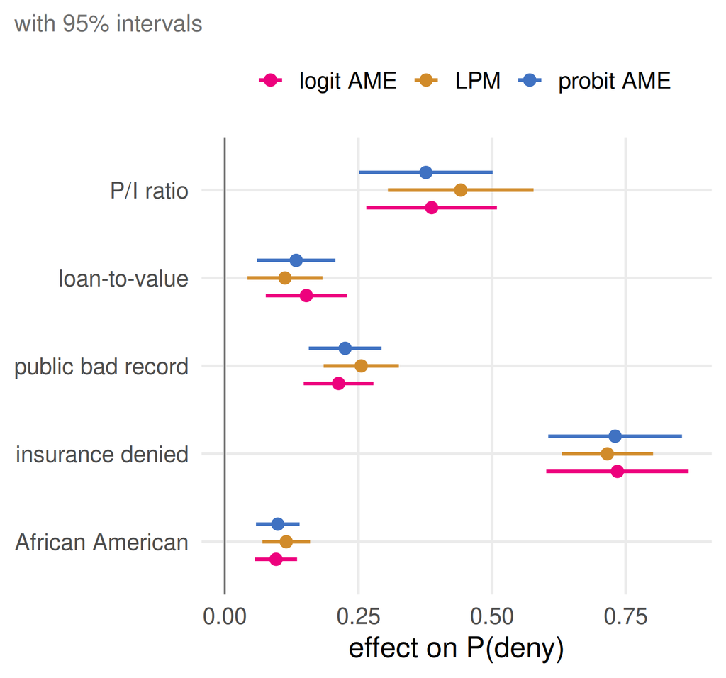

## Predicted Probabilities Tell the Story

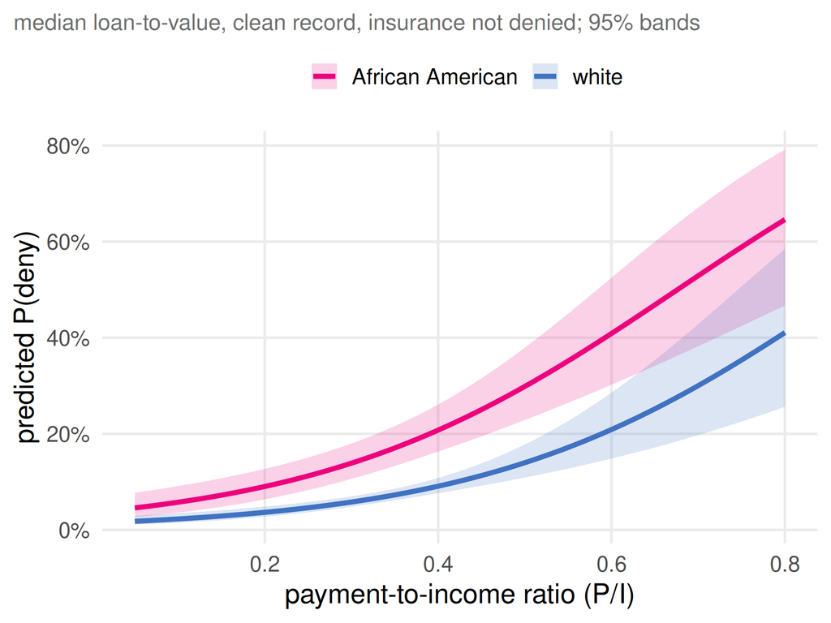

Fix the controls at a **typical applicant** and vary one thing at a time. `predict(..., type = "response")` on a grid of values; build bands on the **link** scale, then transform.

The gap **widens** as P/I rises: in logit and probit the effect of a dummy in **percentage points** depends on the other regressors, even without an interaction term.

**Good practice**

A plot of predicted probabilities for a few meaningful profiles usually communicates better than any table.

## How Well Does It Fit?

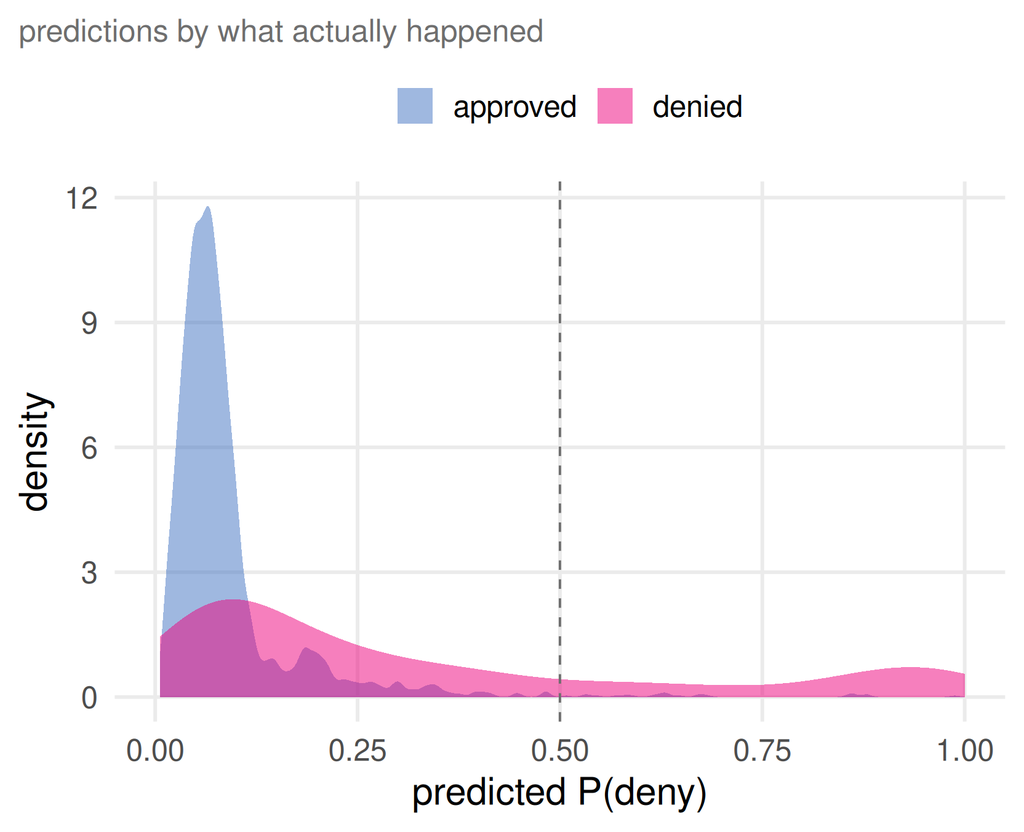

```r
# McFadden pseudo-R²
1 - lg3$deviance / lg3$null.deviance
```

```
[1] 0.2246673
```

```r
table(predicted = fitted(lg3) > 0.5, actual = HMDA$deny)
```

```
         actual
predicted   no  yes
    FALSE 2073  212
    TRUE    22   73
```

- **Pseudo-R²** compares log-likelihoods; values of 0.2–0.4 are already good. Not comparable to OLS R²
- **Accuracy** is 90% — but saying “approve” to everyone scores 88%. With rare outcomes, look at the **distributions**, not the hit rate

## Binary Choice: Practical Advice

**Choosing a model**

- **LPM** with robust SEs: fine for average effects, easy with fixed effects and IV
- **Logit / probit**: when predictions must stay in $[0,1]$ or you care about effects away from the average
- Report **AMEs** or **predicted probabilities**, not raw coefficients

**Traps**

- **Perfect separation**: a regressor predicts $Y$ perfectly; R warns *fitted probabilities numerically 0 or 1* and the coefficient runs off to infinity
- Do not compare raw coefficients **across** models or samples — the scale is not fixed
- **Interactions** in logit/probit: the coefficient on the product is **not** the interaction effect on probabilities

# 3 · A Tour of Other Models

## Match the Model to the Outcome

| Outcome | Example | Model | R |
| --- | --- | --- | --- |
| Continuous | log wage | **linear regression** | `lm()` |
| Binary | mortgage denied | **logit / probit** | `glm(family = binomial)` |
| Ordered categories | health: poor … excellent | **ordered logit / probit** | `MASS::polr()` |
| Unordered categories | car, bus, bike | **multinomial logit** | `nnet::multinom()` |
| Count | doctor visits | **Poisson / negative binomial** | `glm(family = poisson)`, `MASS::glm.nb()` |
| Many zeros, then continuous | hours worked | **Tobit** | `AER::tobit()` |
| Observed only for a selected group | wages of workers | **Heckman selection** | `sampleSelection::selection()` |
| Time until an event | unemployment spell | **duration / survival** | `survival::coxph()` |

**And by data structure or design**

The same unit observed many times $\to$ **panel / fixed effects**. A policy that hits some units at some date $\to$ **difference-in-differences**. An endogenous regressor with an outside source of variation $\to$ **instrumental variables**. Effects that differ across the distribution $\to$ **quantile regression**.

## Ordered and Unordered Choices

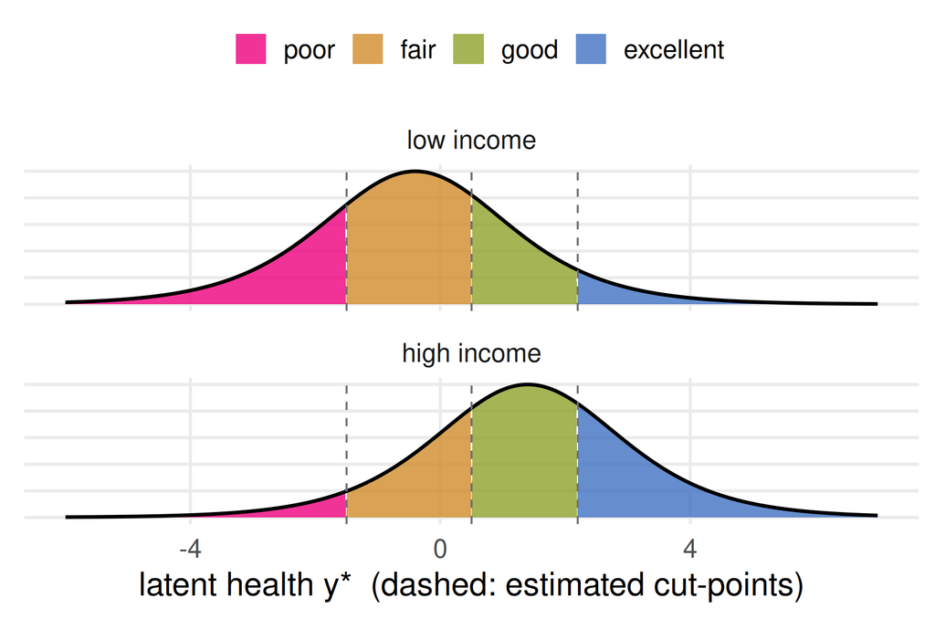

**Ordered: one latent scale, several cut-points**

The binary latent model with **more thresholds**. $X$ shifts the distribution; the areas between cut-points are the probabilities. `MASS::polr()`

**Unordered: one equation per alternative**

Car, bus or bike: no natural order. **Multinomial logit** models each option relative to a base option. `nnet::multinom()`

## Count Data: Poisson and Negative Binomial

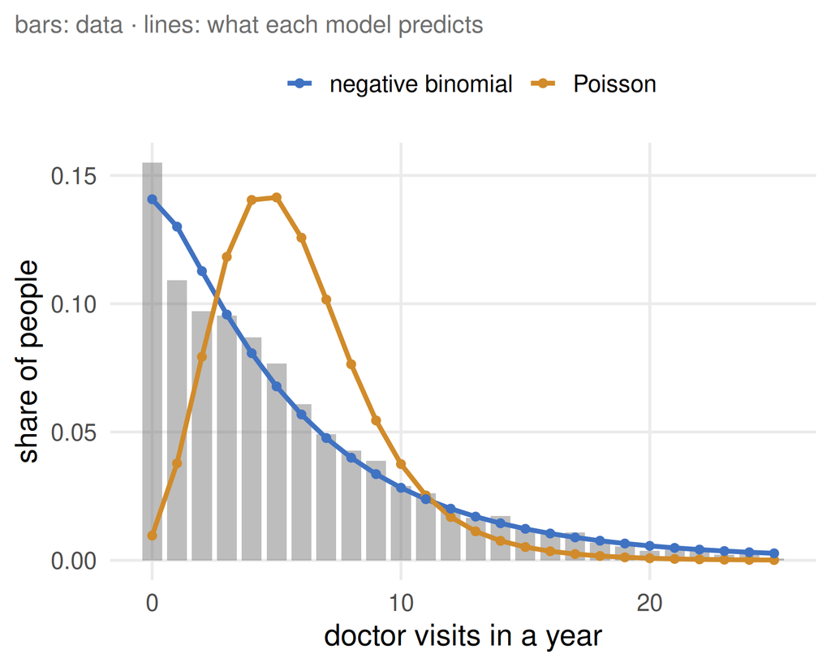

Counts are $0, 1, 2, \ldots$ and skewed. Model the **log of the mean**: $E[Y\mid X] = e^{X\beta}$, so $e^{\beta}-1$ is a **% change**.

Poisson forces variance $=$ mean. Here the mean is 5.8 and the variance 45.7: **overdispersion**. The negative binomial adds a parameter for it — and matches the zeros.

```r
nb <- glm.nb(visits ~ health + chronic + age +
               gender + insurance, data = NMES1988)
round(exp(coef(nb)[c("chronic", "insuranceyes")]), 3)
```

```
     chronic insuranceyes
       1.216        1.388
```

Each chronic condition: **+22%** visits; insurance: **+39%**.

## Corner Solutions: Tobit

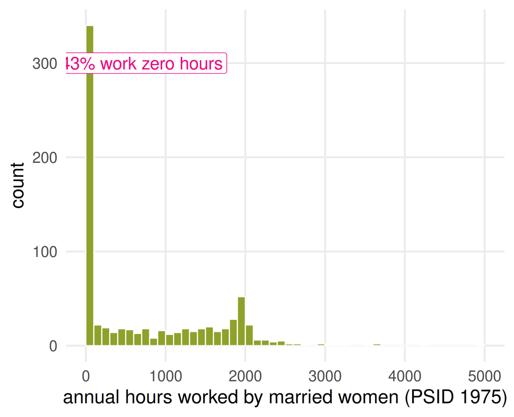

A pile-up at zero: many women **choose** not to work. A straight line through this cloud is pulled toward the zeros.

**Tobit:** latent desired hours $y^* = X\beta + u$; we see $y = \max(0, y^*)$. Estimated by maximum likelihood, like probit for the zeros and OLS for the rest.

```r
PSID1976$nwinc <- with(PSID1976,
                       (fincome - hours * wage) / 1000)
f  <- hours ~ nwinc + education + experience +
              age + youngkids
tb <- tobit(f, data = PSID1976)
round(cbind(OLS   = coef(lm(f, data = PSID1976)),
            Tobit = coef(tb)), 1)
```

```
               OLS  Tobit
(Intercept) 1306.9 1287.8
nwinc         -3.5   -8.5
education     32.7   86.1
experience    46.8   77.4
age          -30.3  -58.3
youngkids   -444.6 -919.9
```

Tobit coefficients refer to **desired** hours $y^*$ and are larger than OLS. For effects on actual hours, compute marginal effects — as with probit.

## Sample Selection

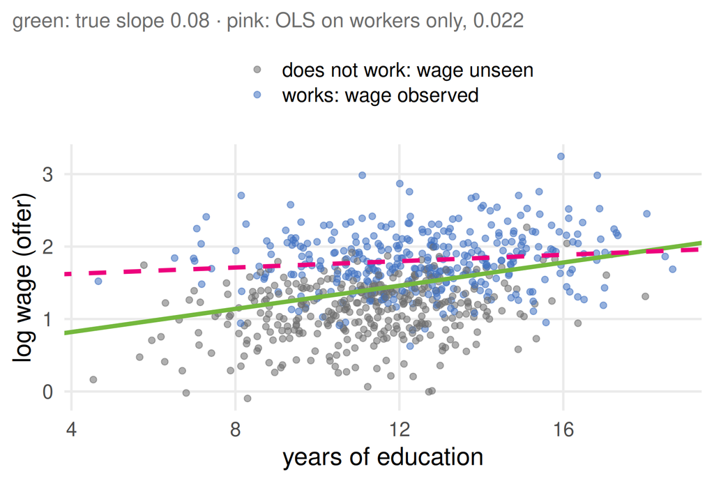

We see wages only for people who **work**. The low-educated work mainly if their offer is **unusually high**, so the slope comes out too **flat**.

**Heckman’s two steps**

1. a **probit** for who works
2. the wage regression plus a correction term from step 1

Needs a variable that shifts **working but not wages** (e.g. young children).

Simulated data. In R: `sampleSelection::selection()`.

## Panel Data: Fixed Effects

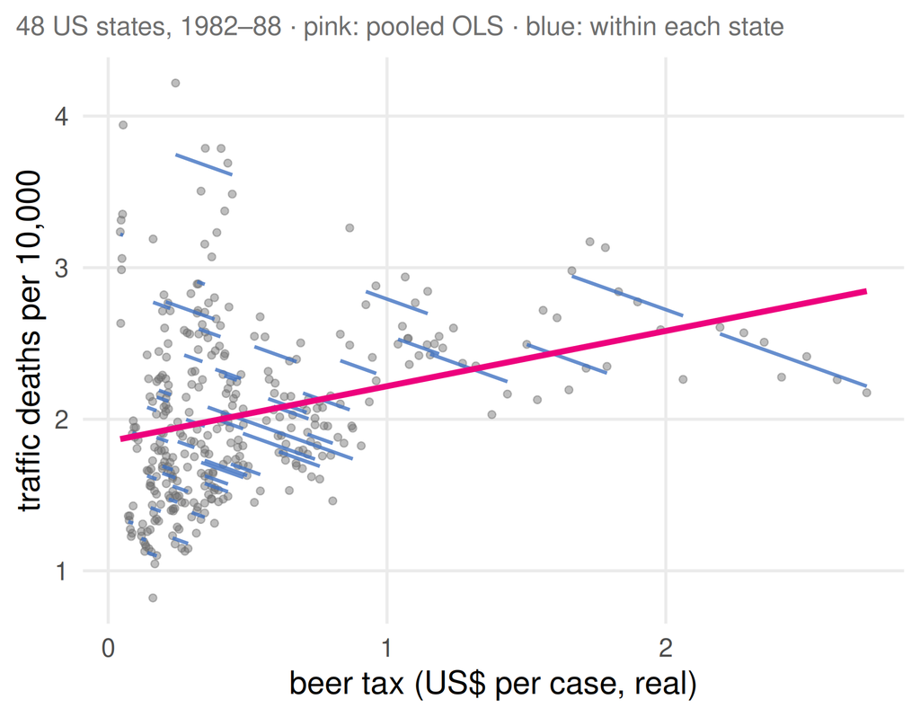

Across states, **higher beer taxes go with more deaths** — because rural, southern states have both. That is omitted variable bias again, from things that differ **between states** but barely change over time.

**Fixed effects**

Give every state its own intercept. The slope is then estimated only from changes **within** a state over time — everything constant about a state drops out, **observed or not**.

The within-state slopes point **down**.

## Fixed Effects in R

```r
library(fixest)
pooled <- feols(frate ~ beertax, Fatalities, cluster = ~state)
fe_s   <- feols(frate ~ beertax | state, Fatalities, cluster = ~state)
fe_st  <- feols(frate ~ beertax | state + year, Fatalities,
                cluster = ~state)
etable(pooled, fe_s, fe_st)
```

```
                           pooled              fe_s             fe_st
Dependent Var.:             frate             frate             frate

Constant        1.853*** (0.1185)
beertax         0.3646** (0.1197) -0.6559* (0.2919) -0.6400. (0.3571) 12
Fixed-Effects:  ----------------- ----------------- -----------------
state                          No               Yes               Yes
year                           No                No               Yes 3
_______________ _________________ _________________ _________________
S.E.: Clustered         by: state         by: state         by: state 4
Observations                  336               336               336
R2                        0.09336           0.90501           0.90893
Within R2                      --           0.04075           0.03606
```

1 Pooled OLS: taxes **raise** deaths?

2 State fixed effects: the sign **flips**. A $1 tax increase goes with 0.66 fewer deaths per 10,000.

3 Year effects also remove nationwide shocks (recessions, safety laws) — the **two-way** FE model.

4 **Clustered** SEs: the 7 years of one state are not independent draws.

## Difference-in-Differences

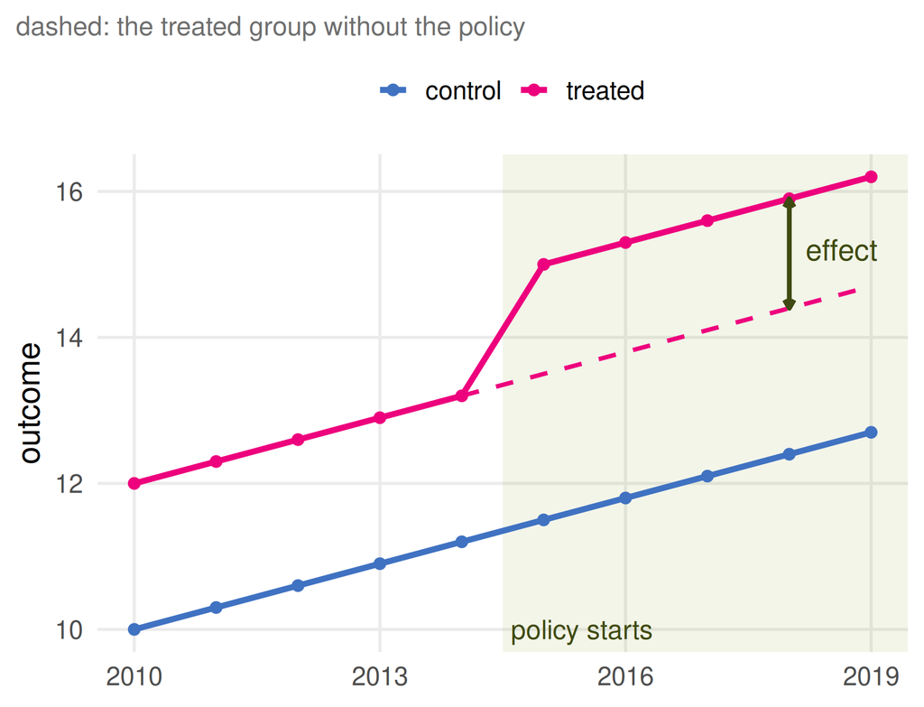

A policy hits **some** units from **some date** on. Compare the change in the treated group with the change in the control group:

$$\hat\delta = (\bar y^{T}_\text{after} - \bar y^{T}_\text{before}) - (\bar y^{C}_\text{after} - \bar y^{C}_\text{before})$$

**Parallel trends**

Without the policy, both groups would have moved **in parallel**. Check the pre-period; that is where the credibility comes from.

In R: `feols(y ~ treated:post | unit + year, data)` — a two-way fixed-effects regression.

## Instrumental Variables

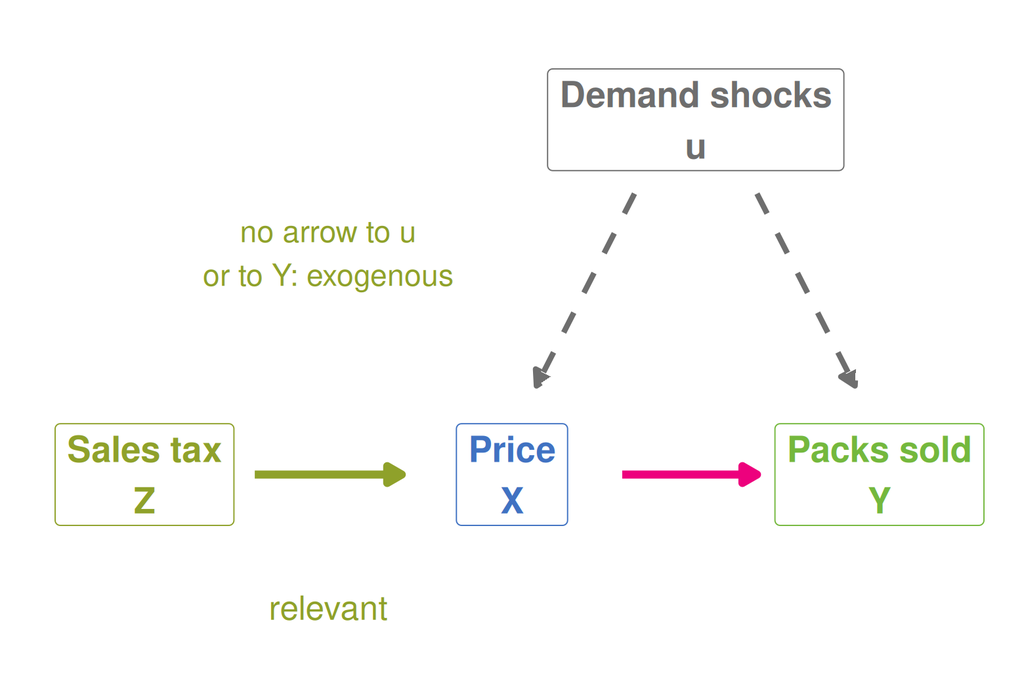

Prices and quantities are set **together** by supply and demand, so price is endogenous in a demand equation.

An **instrument** $Z$ moves $X$ but has no other route to $Y$. Use **only the part of $X$ that $Z$ moves**:

1. regress $X$ on $Z$ (**first stage**) and keep the fitted $\hat X$
2. regress $Y$ on $\hat X$ (**second stage**)

This is **two-stage least squares** (2SLS).

**Two conditions**

**Relevance** — $Z$ really moves $X$: testable.

**Exogeneity** — $Z$ affects $Y$ only through $X$: an argument, not a test.

## IV in R: Cigarette Demand

```r
c95 <- subset(CigarettesSW, year == "1995")
c95 <- transform(c95, rprice = price / cpi, salestax = (taxs - tax) / cpi,
                      rincome = income / population / cpi)
iv <- ivreg(log(packs) ~ log(rprice) + log(rincome) | log(rincome) + salestax,
            data = c95)
summary(iv, diagnostics = TRUE)
```

```
Coefficients:
             Estimate Std. Error t value Pr(>|t|)
(Intercept)    9.4307     1.3584   6.943 1.24e-08 ***
log(rprice)   -1.1434     0.3595  -3.181  0.00266 **  1
log(rincome)   0.2145     0.2686   0.799  0.42867

Diagnostic tests:
                 df1 df2 statistic  p-value
Weak instruments   1  45    45.158 2.65e-08 *** 2
Wu-Hausman         1  44     1.102      0.3     3

Residual standard error: 0.1896 on 45 degrees of freedom
Multiple R-Squared: 0.4189, Adjusted R-squared: 0.3931
Wald test: 6.534 on 2 and 45 DF,  p-value: 0.003227
```

After the `|`: the **instruments** — exogenous regressors (income) plus the excluded instrument (sales tax).

1 Price **elasticity** of demand: a 1% price rise cuts packs sold by 1.14%. OLS gives -1.41.

2 **Weak-instrument** test = first-stage F. Far above the rule-of-thumb 10: the tax is **relevant**.

3 **Wu–Hausman**: OLS and IV do not differ significantly here. With one instrument, **exogeneity** cannot be tested.

## Quantile Regression

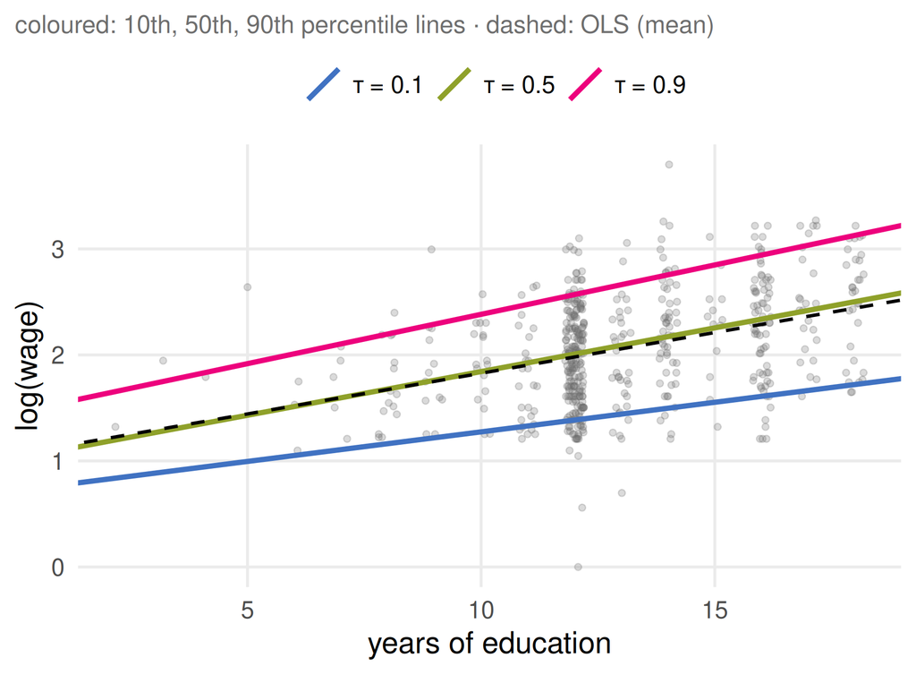

OLS models the **mean**. Quantile regression models a **percentile** of $Y$ given $X$ — e.g. the wage at the bottom 10% of workers with 12 years of school.

```r
qr <- rq(log(wage) ~ education,
         tau = c(0.1, 0.5, 0.9), data = CPS1985)
round(coef(qr), 3)
```

```
            tau= 0.1 tau= 0.5 tau= 0.9
(Intercept)    0.717    1.019    1.453
education      0.056    0.082    0.093
```

Education pays **more at the top**: 5.6% per year at the 10th percentile, 9.3% at the 90th. It also **spreads** wages out. The asymmetric loss from the estimation deck, put to work.

## Also Worth Knowing

**Time series**

**ARIMA** for one series, **VAR** for several that move together. Beware trends: two unrelated trending series look correlated.

**Duration models**

Time until an event — finding a job, a firm exiting. Handle spells still running at the end of the data (**censoring**). `survival::coxph()`.

**Regression discontinuity**

Treatment switches on at a **cut-off** in a running variable (a test score, an age). Compare units just below and just above. `rdrobust`.

**Machine learning meets econometrics**

**Lasso** and **random forests** for prediction and for choosing controls; **double machine learning** for causal effects with many controls.

**The common thread**

Each is a **conditional mean** with a new shape (fitted by least squares or ML), or a **design** that makes $E[u \mid X] = 0$ believable.

# Summary

## Key Takeaways

1. A regression models the **conditional mean** $E[Y\mid X]$. Read every coefficient **in units**
2. `summary()` output: estimate, standard error, $t$ / $z$, p-value, fit. Use **robust** standard errors by default
3. “Holding other things fixed” only holds for what is **in** the model — omitted variables bias the rest
4. For 0/1 outcomes: LPM, logit or probit. Report **marginal effects** or **predicted probabilities**, not raw logit coefficients
5. Let the **outcome** choose the model — and the **design** decide whether the answer is causal

**The one thing to remember**

Every model in this deck answers: **how does the distribution of $Y$ change with $X$?**

The models differ in the **shape** they allow. Whether the answer is **causal** depends on $E[u\mid X]=0$ — and no choice of model can promise that.